# piccr: a quick guide on the data processing

Thomas Münch

2020-01-16

## Introduction

This vignette briefly explains the basic principles of the data processing in **piccr** for correcting and calibrating raw stable isotope data measured on Picarro Inc. devices. The processing follows in principle the methods presented in van Geldern and Barth (2012), but offers more refined and additional options.

We discuss first the basic measurement sequence assumed for the Picarro data processing with **piccr**, before we present the applied processing steps of memory correction, calibration, drift correction, and injection averaging. Finally, we summarise the quality control information offeded by **piccr** and the basic programme workflow.

## Basic measurement sequence

For discrete stable-isotope measurements it is assumed that sample vials are measured alongside standard vials with known isotopic composition. A typical sequence for such measurements, consisting of $N$ vials in total, is three blocks of standard vials, which are placed at the beginning ($b_1$), in the middle ($b_2$) and at the end ($b_3$) of the measurement run, together with sample vials ($s_1$, $s_2$) in between (Fig. 1). This configuration allows using all available processing options in **piccr**:

- memory correction based on the $b_1$ standards;
- calibration and drift correction applying $b_1$ and $b_3$ standards;
- quality control from analysing independent standards placed in $b_2$.

A different number of standard blocks is of course possible and supported; a minimum configuration would be a measurement sequence using only one standard block $b_1$ at the beginning of the measurement, which, however, would not allow to monitor and control for potential machine drift.

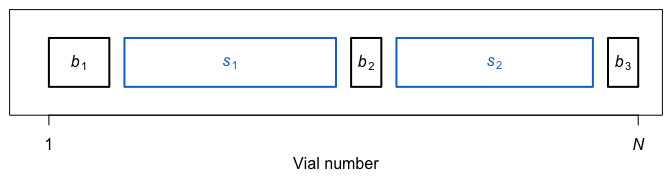

Figure 1: Sketch of a typical Picarro measurement sequence with alternating blocks of standard ($b_i$) and sample ($s_i$) vials. While a minimum configuration of only one standard block at the beginning of the measurement sequence is possible, a configuration with three blocks of standards allows using the full processing functionality of **piccr**.

## Memory correction

### Definitions

The memory effect refers to the carry-over of residual amounts of water vapour in the device’s measurement cavity from one injection to the other, which leads to contamination of the measured isotope value.

To quantifiy this effect, we assume two vials with different standard isotopic compositions (“delta values” in the following); each vial is injected $n$ times into the cavity of the measurement device. Further, let $\delta_v$ denote the true delta value of a standard vial, where $\delta_v^{(1)}$ refers to the first standard and $\delta_v^{(2)}$ to the second standard vial, and let $\delta_c^{j}$ denote the delta value of the water vapour in the cavity for injection $j$. The memory effect for this injection can then be approximated by assuming that the delta value of the water vapour in the cavity is a weighted mean of the true value of the injected vial and the cavity value from the previous injection,

$$\begin{equation}
\delta_c^{j}=(1-\tilde{m})\delta_v + \tilde{m}\delta_c^{j-1},
\tag{1}
\end{equation}$$

where $\tilde{m}$ is the general memory coefficient of the measurement system, which quantifies the fraction of water vapour in the cavity which stems from the previous injection. Likewise, for injections $j+1$ and $j+2$ we have

$$\begin{align}
\delta_c^{j+1}&=(1-\tilde{m})\delta_v + \tilde{m}\delta_c^{j}, \tag{2}\\
\delta_c^{j+2}&=(1-\tilde{m})\delta_v + \tilde{m}\delta_c^{j+1}. \tag{3}
\end{align}$$

By inserting $\delta_c^{j}$ into $\delta_c^{j+1}$ and $\delta_c^{j+1}$ into $\delta_c^{j+2}$, one finds for injection $j+k$

$$\begin{equation}
\delta_c^{j+k} = (1-\tilde{m}^{k+1})\delta_v + \tilde{m}^{k+1}\delta_c^{j-1}.
\tag{4}
\end{equation}$$

We now set $i=j+k$ and define $j$ to be first injection from the second standard vial, thus $j=1$. Then, the cavity value of the previous injection, $\delta_c^{j-1}$, is the last injection from the first standard vial and thus very close to the true value for that vial, $\delta_c^{j-1}\approx\delta_v^{(1)}$. The cavity value for injection $i$ from the second standard vial is thus in general

$$\begin{equation}
\delta_c^{i} = (1-\tilde{m}^{i})\delta_v^{(2)} + \tilde{m}^{i}\delta_v^{(1)}.
\tag{5}
\end{equation}$$

From here, we can define the injection-specific memory coefficient as

$$\begin{equation}
m_i:=1-\tilde{m}^{i},
\tag{6}
\end{equation}$$

which describes the fraction of vapour in the cavity which stems from the current injection $i$. By combining Eqs. (5) and (6), one can derive an expression for $m_i$,

$$\begin{equation}
m_i = \frac{\delta_c^{i} - \delta_v^{(1)}}{\delta_v^{(2)} - \delta_v^{(1)}}.
\tag{7}
\end{equation}$$

### Correcting for the memory effect

The memory-corrected value for an injection $i$ from the second standard vial, $\delta_{\text{mem.-corr.}}^{i}$, is the true delta value for this vial, i.e. $\delta_v^{(2)}$. Solving Eq. (5) for $\delta_v^{(2)}$ and using Eq. (6) yields

$$\begin{equation}
\begin{split}
\delta_{\text{mem.-corr.}}^{i} &=
\delta_c^{i} + \frac{1-m_i}{m_i}\left(\delta_c^{i} - \delta_v^{(1)}\right),\\
&\approx \delta_c^{i} +
\left(1-m_i\right)\left(\delta_c^{i} - \delta_v^{(1)}\right)
\ \text{for}\ m_i \lesssim 1,\\
&=\delta_c^{i} + \tilde{m}^{i}\left(\delta_c^{i} - \delta_v^{(1)}\right).
\end{split}
\tag{8}
\end{equation}$$

In **piccr**, the full expression, i.e. the first line of Eq. (8), is used for the correction. The second line is the approximation as given in van Geldern and Barth (2012).

### Estimating and applying the memory coefficients

To estimate the memory coefficients for a specific measurement sequence, $N_s$ standard vials with different isotopic composition are placed in block $b_1$. Each standard is injected $n_I$ times, where $n_I$ needs to be large enough to ensure that the measured values of the last injections are close to the true value of the vial (e.g., $n_I = 12$). From the raw measurement data for each standard of number $2$ to $N_s$, memory coefficients in **piccr** are then estimated as follows:

- The $m_i$ for each standard are estimated from Eq. (7). For this, the $\delta_v$ values are approximated with the mean across the last three injections of the respective standard.
- The mean $m_i$ across the $N_s-1$ standards are calculated and applied for the correction in Eq. (8).

## Calibration and drift correction

### Calibration

The raw output data (i.e. memory-corrected or not) from Picarro Inc. devices need to be calibrated to the international VSMOW/SLAP scale of water isotopic composition. For this, standards with known isotopic composition are used.

In **piccr**, the calibration is performed by linearly regressing the true values of $N_s$ standards measured in some block $b_i$ against the measured values from the injections. The number of calibration standards $N_s$ is settable: naturally, the minimum is to use two calibration standards, but it is also possible to use three or all standards from the block. If memory correction has been applied, all injections are used for the regression, else only the last three injections to avoid the memory effect from affecting the calibration.

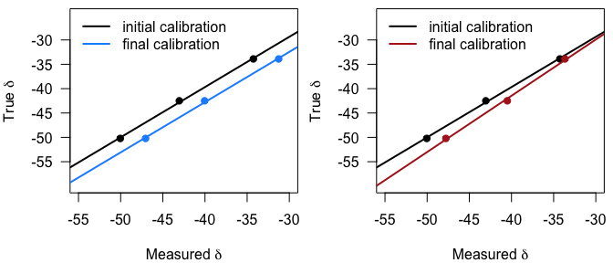

Figure 2: Schematic sketch of a linear calibration regression using three standards. (**Left**) The regression from the initial standard block $b_1$ is compared to the regression from the final standard block $b_3$ assuming a constant, linear drift of the measurement values over time, which changes the calibration intercept at the final compared to the initial block but leaves the calibration slope unchanged. (**Right**) Same as (left) but assuming a linear drift that is stronger for more negative delta values. This changes both the calibration slope and intercept at the final block. Note that for visibility, the magnitude of the device drift is exaggerated in both examples.

The linear regression yields a calibration intercept $I$ and a calibration slope $s$ (as illustrated by the black lines in Fig. 2). The raw measurement data are then calibrated to the true scale using

$$\begin{equation}
\delta_\text{calib} = s\cdot\delta_\text{raw} + I.
\tag{9}
\end{equation}$$

### Drift

For longer measurement runs Picarro Inc. devices exhibit drift (van Geldern and Barth, 2012), i.e. the measured delta values gradually shift over time. This has an influence on the calibration parameters depending on the type of the drift.

#### Constant linear drift

Assuming a constant linear drift, the measured data drifts at the same rate independent of the delta value (Fig. 2, left). **piccr** estimates this kind of drift by linearly regressing the standards commonly measured in all three blocks $b_1$–$b_3$ against the measurement time relative to $b_1$. Again, only if memory correction was applied, all standard injections are used for this, else only the last three. The regression yields a regression slope for each standard (Fig. 3), and the drift rate $\alpha$ is estimated with the average regression slope. Then, the measured (memory-corrected) delta values are drift-corrected using

$$\begin{equation}\label{eq:drift.corr.}
\delta_\text{drift-corr.} = \delta_\text{mem.-corr.} - \alpha t,
\tag{10}
\end{equation}$$

where $t$ is the measurement time (van Geldern and Barth, 2012).

Subsequently, a calibration is performed using the calibration parameters calculated from the standards in $b_1$ (intercept $I_1$, slope $s_1$) and applying Eq. (9).

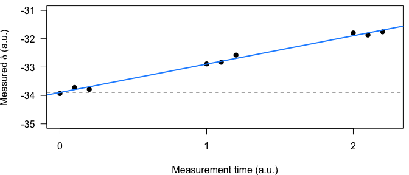

Figure 3: Schematic sketch of a device drift with a constant rate that gradually shifts the measured delta values of a given standard over time.

Approximately, this correction can be interpreted jointly as a time-variable calibration (Fig. 2, left) with a constant calibration slope, but where the calibration intercept varies linearly with time between $b_1$ and $b_3$ according to the drift rate $\alpha$,

$$\begin{equation}
\begin{split}
I(t) &= I_1 + \alpha t,\\
s(t) &= s_1 = \text{const.}
\end{split}
\tag{11}
\end{equation}$$

#### Delta-dependent linear drift

More generally, the device can exhibit a linear drift that is not constant but dependent on the delta value. Such a drift pattern does not only affect the calibration intercept but also the calibration slope over time (Fig. 2, right), and a time-dependent calibration has to be defined according to

$$\begin{equation}
\begin{split}
I(t) &= I_1 + \alpha t,\\
s(t) &= s_1 + \beta t.
\end{split}
\tag{12}
\end{equation}$$

Here, $\alpha$ and $\beta$ are the rates at which the calibration parameters change over time.

To estimate $\alpha$ and $\beta$, **piccr** calculates calibration parameters (i.e. intercept and slope) from both the $b_1$ and $b_3$ blocks and regresses these parameters against the measurement time. The slopes of each regression then yield the $\alpha$ and $\beta$ rates, respectively. More specifically, the $b_1$ calibration yields the calibration parameters $I_1$ and $s_1$, and the $b_3$ calibration the calibration parameters $I_3$ and $s_3$. Then, the drift rates are given by

$$\begin{align}
\alpha \simeq \frac{I_3 - I_1}{\Delta t}, \tag{13}\\
\beta \simeq \frac{s_3 - s_1}{\Delta t}, \tag{14}
\end{align}$$

where $\Delta t$ is the measurement time that passed between $b_1$ and $b_3$. The raw (memory-corrected) data are then jointly drift-corrected and calibrated using the $I(t)$ and $s(t)$ of Eq. (12) in Eq. (9).

## Sample value from injection average

To increase measurement precision, the final isotopic value of a given measured sample after all previous processing steps is obtained from averaging across a given number of injections. Without memory correction, the first injections should be discarded from the average to limit the influence of the memory effect on the mean sample value. However, since **piccr** provides an active memory correction, all injections can be used to calculate the sample average.

The possible options in **piccr** to perform this averaging step therefore are:

- average over all available injections for each sample;
- average across the last $n$ injections;
- average across a range of injections from injection number $n_1$ to $n_2$.

## Quality control

Quality control of the measured and processed data is possible with **piccr** on four levels: (1) per-injection basis, (2) per-sample basis, (3) per-file basis, and (4) per-project basis.

These information are based on actual data measured by the Picarro device, on parameter data from the **piccr** processing steps, and on data obtained from the deviations of the measured and processed standard values compared to their expected (“true”) values. For this, it is recommended to use an independent quality control standard in the measurement, which is not used for any processing steps and is preferably placed in the $b_2$ block.

### Per-injection basis

On this level, the following quality control information is obtained directly from the Picarro measurement files:

- standard deviation of the injection value for each measured isotopic species from the measurement integration time in the cavity;
- water vapour level (mean and standard deviation) during the injection.

The cavity water vapour level during an injection should typically lie between 18000 and 22000 ppm. Deviations from this optimal range may result in large standard deviations of the measured isotope values. Taken together, these information can be used to sort out “bad” injections.

Since **piccr** also returns the raw data, as read in from the measurement files, these quality control information are readily available for further analysis.

### Per-sample basis

The final isotopic value of the sample is obtained from averaging across a certain number of injections (see above). From this injection average, **piccr** calculates the following quality control information:

- the mean water vapour level and its standard deviation;
- the standard deviation of the mean isotope value for each isotopic species;
- the deviation from the true isotope value (only for standards).

These data are a measure for the overall goodness of the measured value of the sample and can provide information on the stability of consecutive measurements or help to identify outliers.

### Per-file basis

On this level, **piccr** provides the following quality control information:

- the specific deviation from the true value for the independent quality control standard;
- the root mean square deviation across the deviations of all measured standards from their true values;
- the pooled standard deviation across all measured samples and standards;
- quality control information from the memory correction process: mean memory coefficients and the individual coefficients as estimated from each analysed standard;
- quality control information from the calibration process (*to be specified*);
- quality control information from the drift correction process (*to be specified*).

The deviation of the independent quality control standard, and the root mean square deviation of all measured standard values from their true values serve as an overall measurement uncertainty for the run. The root mean square deviation is defined as

$$\begin{equation}
\sigma_\text{rmsd} =
\sqrt{\frac{1}{k}\sum_{i=1}^{k}{\left(\Delta\delta_i\right)^2}},
\tag{15}
\end{equation}$$

where $\Delta \delta_i$ is the deviation of the measured value from its true value for standard $i$, $\Delta\delta_i=\delta_t - \delta_m$, and $k$ is the number of standards.

The pooled standard deviation $\sigma_\text{p}$ is the square root of the pooled variance which is defined as

$$\begin{equation}
\sigma_\text{p}^2 =
\frac{\sum_{i=1}^{N}{(n_i-1)\sigma_i^2}}{\sum_{i=1}^{N}{(n_i-1)}},
\tag{16}
\end{equation}$$

where $\sigma_i$ is the standard deviation of the mean isotope value for vial $i$ from averaging across $n_i$ injections, and $N$ is the total number of analysed vials. The pooled variance is an estimate of the fixed common variance from populations that have different means. If the number of injections is the same for all vials (populations), $n_i=n=\text{const}$, the pooled variance is simply the average across all variances $\sigma_i^2$. The pooled standard deviation provides a measure for the overall stability of consecutive injections.

### Per-project basis

The overall measurement uncertainty for a given measurement project, which contains $M$ single measurements (i.e. Picarro files), is assessed with the root mean square deviation of the quality control standards,

$$\begin{equation}
\sigma_\text{rmsd}^{\text{project}} =
\sqrt{\frac{1}{M}\sum_{i=1}^{M}{\left(\Delta\delta_{i}^{\text{qlty-contr}}\right)^2}},
\tag{17}
\end{equation}$$

where $\Delta\delta_{i}^{\text{qlty-contr}}$ is the deviation for measurement file $i$ of the quality control standard from its true value (either the simple deviation, or the root mean square deviation if more than one independent quality control standards have been used in this file).

## Programme work flow

In summary, the basic programme workflow in **piccr** for correcting and calibrating the raw data is:

1. if (use_memory_correction):
   - calculate memory coefficients;
   - apply memory correction, Eq. (8).
2. if (no_drift_correction):
   - obtain calibration intercept and slope from $b_1$ standards;
   - apply calibration, Eq. (9).

   else if (use_simple_drift_correction):
   - calculate drift slope $\alpha$;
   - drift-correct data, Eq. (10);
   - obtain calibration intercept and slope from $b_1$ standards;
   - apply calibration, Eq. (9).

   else if (use_double_calibration):
   - obtain calibration intercept and slope from $b_1$ and $b_3$ standards;
   - linearly regress calibration parameters between $b_1$ and $b_3$, Eqs. (13)–(14);
   - apply calibration, Eq. (12) and Eq. (9).
3. calculate average values across injections.
4. obtain quality control information.

## References

van Geldern, R. and Barth, J. A.: Optimization of instrument setup and post-run corrections for oxygen and hydrogen stable isotope measurements of water by isotope ratio infrared spectroscopy (IRIS), Limnol. Oceanogr. Methods, 10, 1024–1036, DOI: 10.4319/lom.2012.10.1024, 2012.